# Tax Cuts And Their Effect On The U.S. Housing Market

# U.S. Housing Market Over 5 Year Intervals

The housing market has gone through many changes over the last 20 years. The best way to view the effect on home buyers would be to view in 5 year intervals.

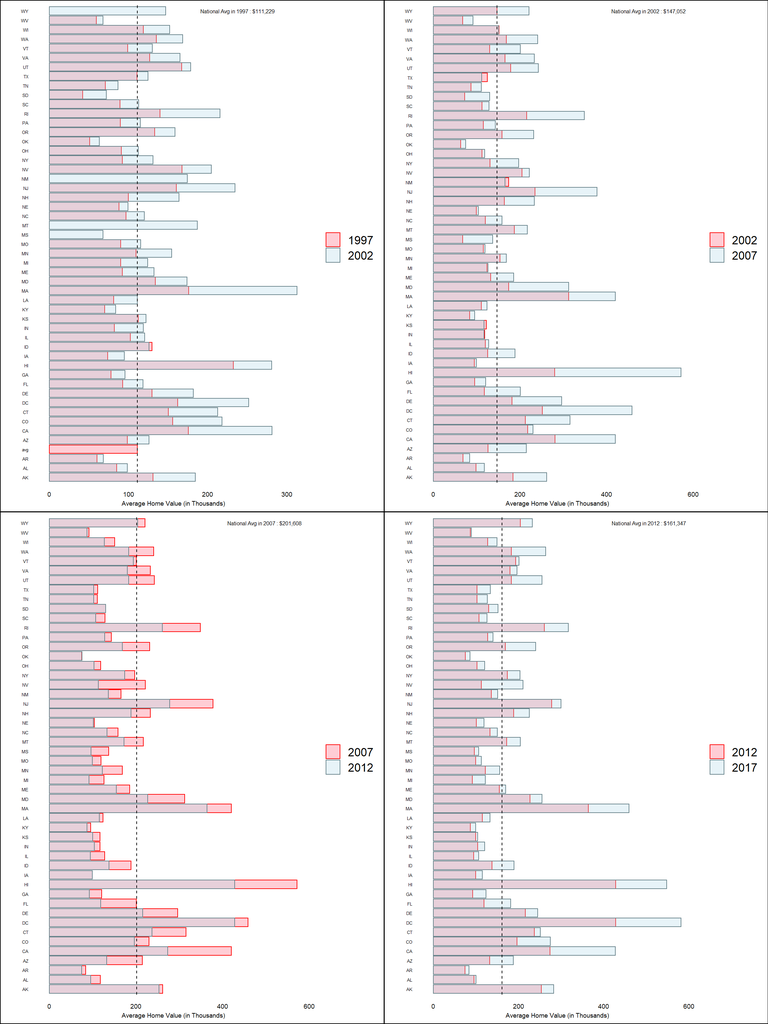

Source: Zillow ZHVI allhomes dataset  
Years : 1997-2017

# Average Housing Prices In 2017

Average housing prices in each state and D.C. in 2017 as compared to the national average. Note that D.C. is an urban area and does not have the population or size as compared to the remaining states.

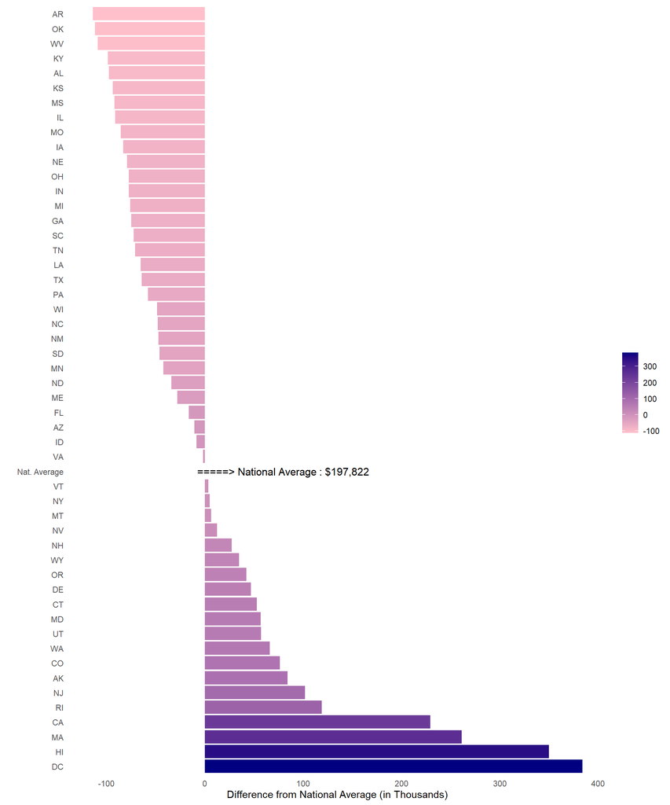

Source: Zillow ZHVI allhomes dataset  
Years : 2017

# Percent Of Working Population

The percent of the population that is currently working and is between the ages of 20-65 (as defined by the census- ACS).

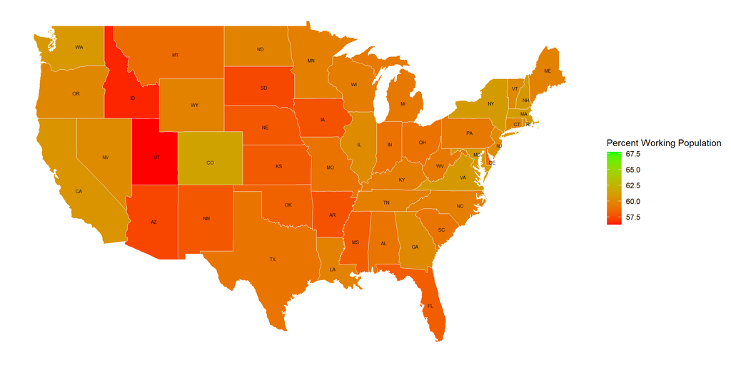

Source: ACS Demographics Dataset  
Years : 2016

# Average Total Taxes Collected By States

The income taxes collected by state governments averaged across all states as compared to the average corporate net income taxes and the average property taxes. Even with significant tax cuts in 1981 and 1986 by President Reagan, 1997 by President Clinton, and 2001 by President George W. Bush, wages have increased leading to increased revenue by states. Property taxes appear to be significantly smaller in comparison over the same period.

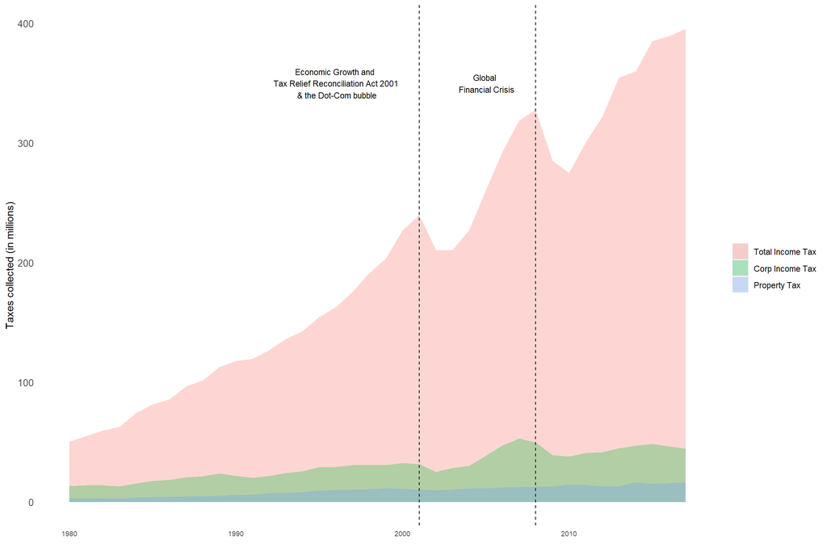

Source: ACS Tax Collection Dataset  
Years : 1980-2017

# The Average Effect Of Tax Collections On Housing Prices

The impact of taxes on housing prices suggests that there is a linear correlation between the two in periods of economic stability, (1996-2001,2003-2007, and 2011-2017). However, in times of economic turmoil (2001-2002 and 2007-2008), this correlation is lost.

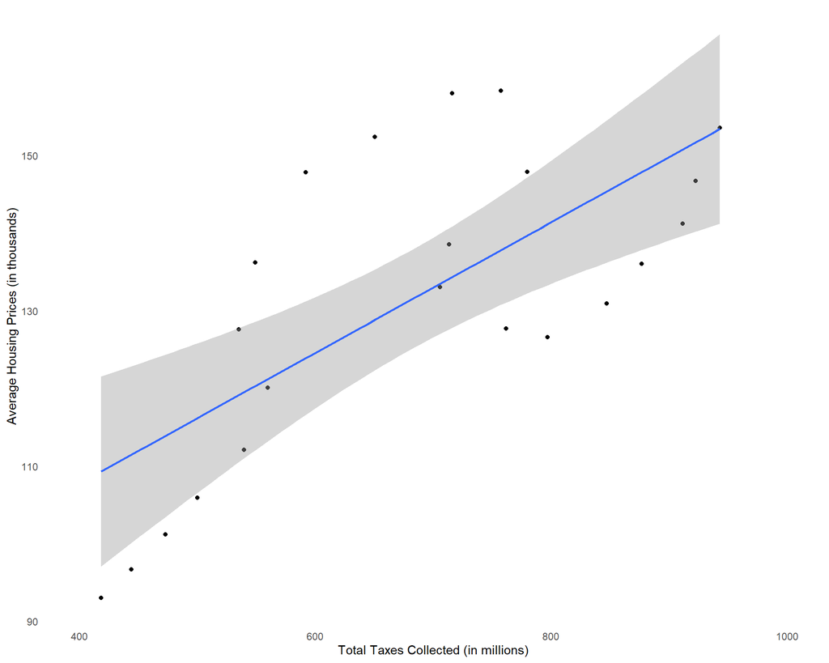

Source: ACS Tax Collection and Zillow ZHVI all homes datasets  
Years : 1996-2017